# Lab 9

Aliza Fassler

11/10/2021

I worked with Sonja Glasser, Justin Roche and Joshua Driscoll on this lab.

# **Q1 (1 pt.): State the null hypothesis of the Chi-square test.**

**Make sure you state the null hypothesis in terms of Brown Creeper presence/absence and edge/interior habitats.**

The null hypothesis of the chi-square test is that there is no relationship between brown creeper habitat type (edge or interior) and brown creeper presence/absence.

# **Q2 (2 pts.): Consider the results of your test and explain whether you think that Brown Creepers show a significant habitat preference.**

**Make sure your use the output of your statistical test to support your answer.**

# **Q3 (1 pt.): Show the R-code you can use to create a model fit (call it fit_species) of penguin body mass as predicted by penguin species**

```r
fit_species =
  lm(
    formula = body_mass_g ~ species,
    data = penguins)
```

# **Q4 (1 pt.): Show the R-code you can use to create a model fit (call it fit_sex) of penguin body mass as predicted by sex.**

```r
fit_sex =
  lm(
    formula = body_mass_g ~ sex,
    data = penguins)
```

# **Q5 (1 pt.): Show the R-code you can use to create a model fit (call it fit_both) of penguin body mass as predicted by species and sex.**

```r
fit_both =
  lm(
    formula = body_mass_g ~ species*sex,
    data = penguins)
```

# **Q6 (1 pt.): Include a conditional boxplot corresponding to your fit_species model.**

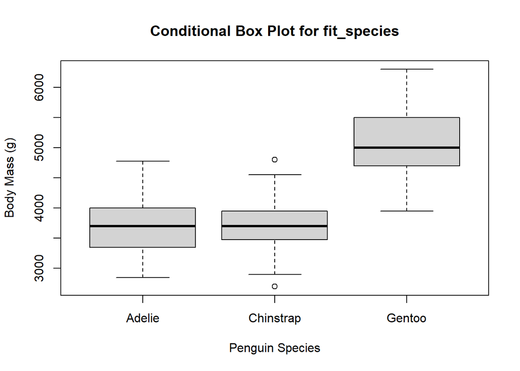

```r
boxplot(data=penguins, body_mass_g ~ species, xlab = "Penguin Species", main = "Conditional Box Plot for fit_species", ylab = "Body Mass (g)" )
```

# **Q7 (1 pt.): Include a conditional boxplot corresponding to your fit_sex model.**

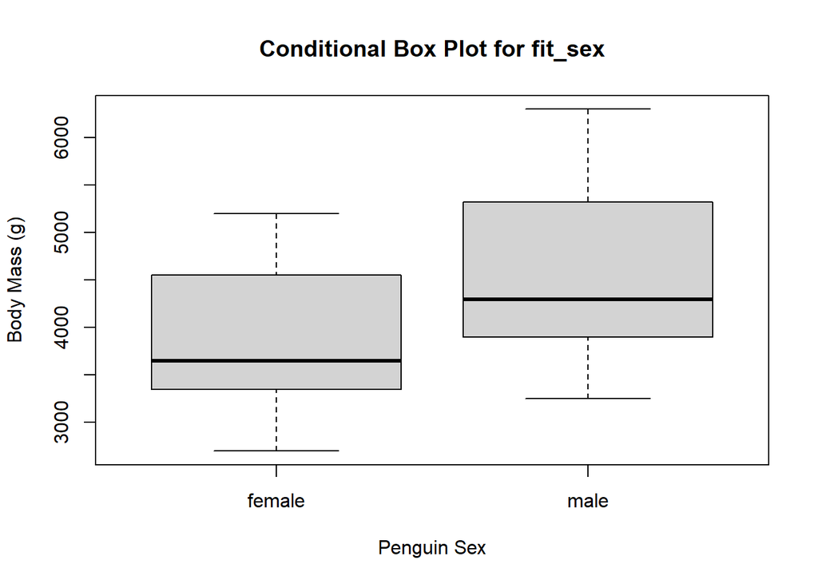

```r
boxplot(data=penguins, body_mass_g ~ sex,
        xlab = "Penguin Sex",
        main = "Conditional Box Plot for fit_sex",
        ylab = "Body Mass (g)" )
```